# Supplementary Reference Analysis - Coefficient Approach

## 1.3 A. Volcano plot of interaction genes

Use volcano plot to show the interaction results.

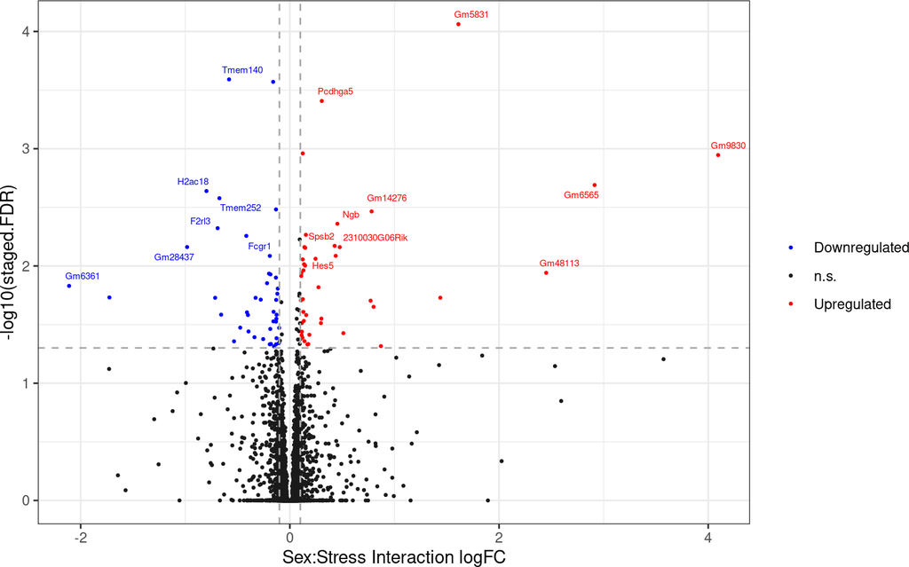

```r
show <- row.names(Results_interaction)[which(Results_interaction$staged.FDR < 0.015 & abs(Results_interaction$logFC) > 0.25)]
sup_fig_coef_a <- volcano(Results_interaction, logFC = logFC, signif = staged.FDR, labels = show) +
  coord_cartesian(xlim = c(-2.1,4.09)) + labs(x = "Sex:Stress Interaction logFC")
sup_fig_coef_a
```

## 1.4 B. Heatmap of interaction genes

Use heatmap to show the interaction results.

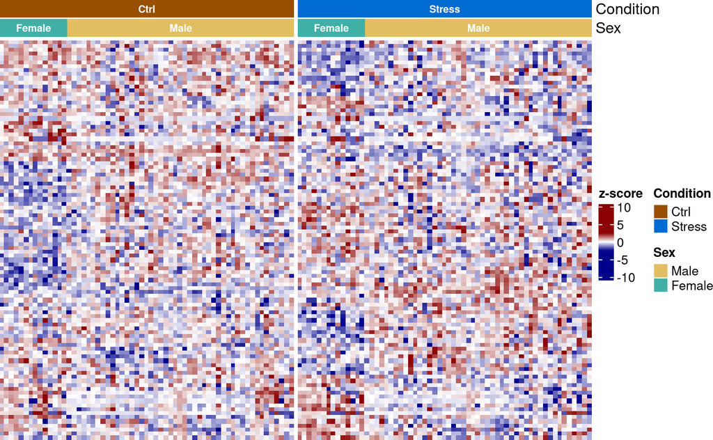

```r
sup_fig_coef_b <- sechm(
  se = se,
  feature = intDEGs,
  gaps_at = "Condition",
  assayName = "corrected",
  top_annotation = c("Condition", "Sex"),
  anno_labels = TRUE,
  anno_label_gp = list(size = 8, col = "white"),
  do.scale = TRUE,
  name = "z-score",
  show_rownames = FALSE,
  cluster_rows = TRUE,
  show_row_dend = FALSE,
  breaks = 0.98,
  column_title = NULL,
  use_raster = TRUE
)
sup_fig_coef_b
```

## 1.5 C. The correlation of interaction logFC and baseline logFC between sexes

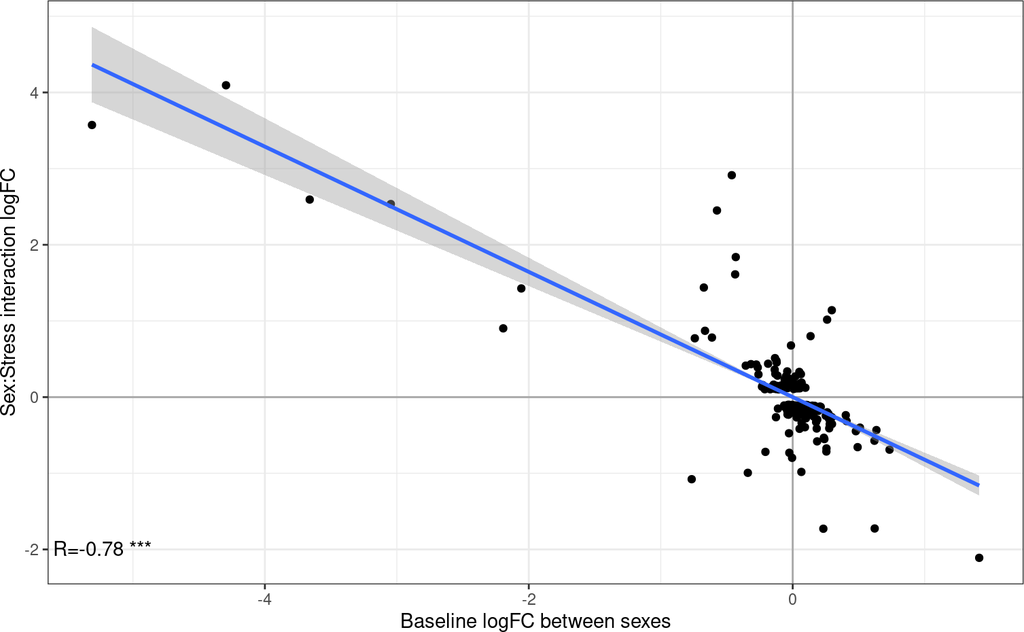

```r
Results_interaction$logFC.Sex <- Results_sex[row.names(Results_interaction), "logFC"]
Results_interaction$logFC.stressMales <- Results_M[row.names(Results_interaction), "logFC"]

Results_interaction2 <- Results_interaction[which(Results_interaction$staged.FDR < 0.15 & abs(Results_interaction$logFC) > 0.1),]
ct <- cor.test(Results_interaction2$logFC, Results_interaction2$logFC.Sex)
sup_fig_coef_c <- ggplot(Results_interaction2, aes(logFC.Sex, logFC)) +
  geom_vline(xintercept = 0, colour = "darkgray") +
  geom_hline(yintercept = 0, colour = "darkgray") +
  geom_point() +
  geom_smooth(formula = y ~ 0 + x, method = "lm") +
  theme_bw() +
  labs(x = "Baseline logFC between sexes", y = "Sex:Stress interaction logFC") +
  annotate("text", x = -Inf, y = -Inf, label = paste0(" R=", round(ct$estimate,2)," ***\n"), hjust = 0, vjust = 0)
sup_fig_coef_c
```

## 1.6 Improved stageR Strategy

```r
# use stagedFDR to boost power for Sex*Stress (interaction term)
# Here we use everything except for Male.vs.Female as the screening model
Results_Screen2 <- as.data.frame(topTags(glmQLFTest(fit, grep("Condition", colnames(mm), value=TRUE)), Inf))
pScreen2 <- Results_Screen2$PValue
names(pScreen2) <- rownames(Results_Screen2)
pConfirmation2 <- cbind(Interaction = Results_interaction[row.names(Results_Screen2),"PValue"])
stageRObj2 <- stageR(pScreen = pScreen2, pConfirmation = pConfirmation2, pScreenAdjusted = FALSE)
stageRObj2 <- stageWiseAdjustment(object = stageRObj2, method = "none", alpha = 0.05)

adj_PVals2 <- getAdjustedPValues(stageRObj2, onlySignificantGenes = FALSE, order = FALSE) #returns NA for non-significant gene in pScreen
```

```
## The returned adjusted p-values are based on a stage-wise testing approach and are only valid for the provided target OFDR level of 5%. If a different target OFDR level is of interest,the entire adjustment should be re-run.
```

```r
adj_PVals2 <- as.data.frame(adj_PVals2)

Results_interaction$staged.FDR <- adj_PVals2[rownames(Results_interaction),]$"Interaction"
intDEGs2 <- rownames(na.omit(Results_interaction[Results_interaction$staged.FDR < 0.05, ]))
intDEGs2
```

```
##  [1] "ENSMUSG00000111133.Gm5831"        "ENSMUSG00000057137.Tmem140"
##  [3] "ENSMUSG00000047409.Ctdspl"        "ENSMUSG00000103567.Pcdhga5"
##  [5] "ENSMUSG00000075478.Slitrk1"       "ENSMUSG00000094437.Gm9830"
##  [7] "ENSMUSG00000079224.Gm6565"        "ENSMUSG00000064220.H2ac18"
##  [9] "ENSMUSG00000048572.Tmem252"       "ENSMUSG00000039257.Vstm2b"
## [11] "ENSMUSG00000082163.Gm14276"       "ENSMUSG00000021032.Ngb"
## [13] "ENSMUSG00000050147.F2rl3"         "ENSMUSG00000005370.Msh6"
## [15] "ENSMUSG00000015947.Fcgr1"         "ENSMUSG00000041078.Grid1"
## [17] "ENSMUSG00000101111.Gm28437"       "ENSMUSG00000029034.Ints11"
## [19] "ENSMUSG00000032062.2310030G06Rik" "ENSMUSG00000048001.Hes5"
## [21] "ENSMUSG00000048546.Tob2"          "ENSMUSG00000038742.Angptl6"
## [23] "ENSMUSG00000018425.Dhx40"         "ENSMUSG00000025815.Dhtkd1"
## [25] "ENSMUSG00000037110.Ralgapa2"      "ENSMUSG00000024414.Mrpl27"
## [27] "ENSMUSG00000052748.Swt1"          "ENSMUSG00000020696.Rffl"
## [29] "ENSMUSG00000021236.Entpd5"        "ENSMUSG00000005699.Pard6a"
## [31] "ENSMUSG00000060862.Zbtb40"        "ENSMUSG00000068964.Gm6361"
```

## 1.7 D. Comparison of logFCs upon Stress in males and females

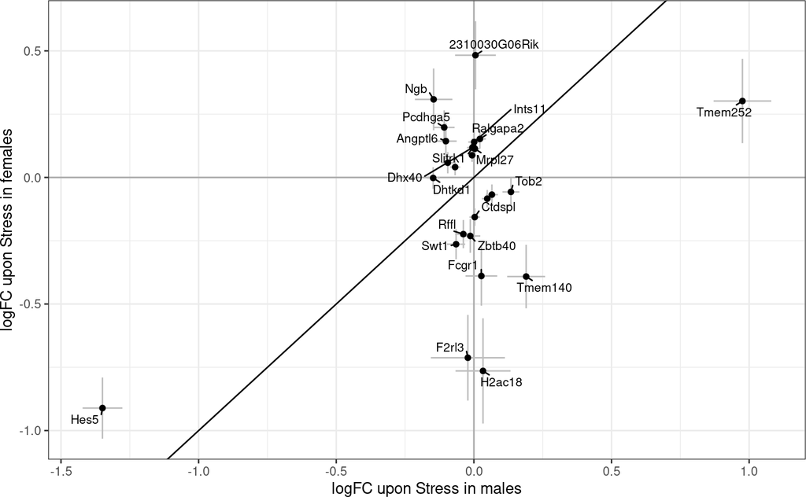

```r
merge_M_F <- merge(Results_M, Results_F, by = "row.names", suffix = c(".males", ".females"))

merge_M_F$proteinCoding <- rowData(se)[merge_M_F$Row.names, "proteinCoding"]

merge_M_F <- merge_M_F[which(merge_M_F$Row.names %in% intDEGs2 & merge_M_F$proteinCoding),] # select protein-coding genes with significant Sex*Stress interaction

sup_fig_coef_d <- ggplot(merge_M_F, aes(logFC.males, logFC.females)) +
  geom_vline(xintercept = 0, colour = "darkgray") +
  geom_hline(yintercept = 0, colour = "darkgray") +
  geom_abline(slope=1) +
  geom_segment(aes(y=low.females, yend=high.females), color="grey") +
  geom_segment(aes(x=low.males, xend=high.males), color="grey") +
  theme_bw() +
  geom_point() +
  ggrepel::geom_text_repel(data=merge_M_F[which(abs(merge_M_F$logFC.males)>0.1 | abs(merge_M_F$logFC.females)>0.1),],
    aes(label=gsub(".+\\.","",Row.names)), max.overlaps = 30, min.segment.length = 0, size=3) +
  labs(x="logFC upon Stress in males", y="logFC upon Stress in females")
sup_fig_coef_d
```

## 1.8 E. Heatmap of protein-coding genes with significant Sex*Stress interaction

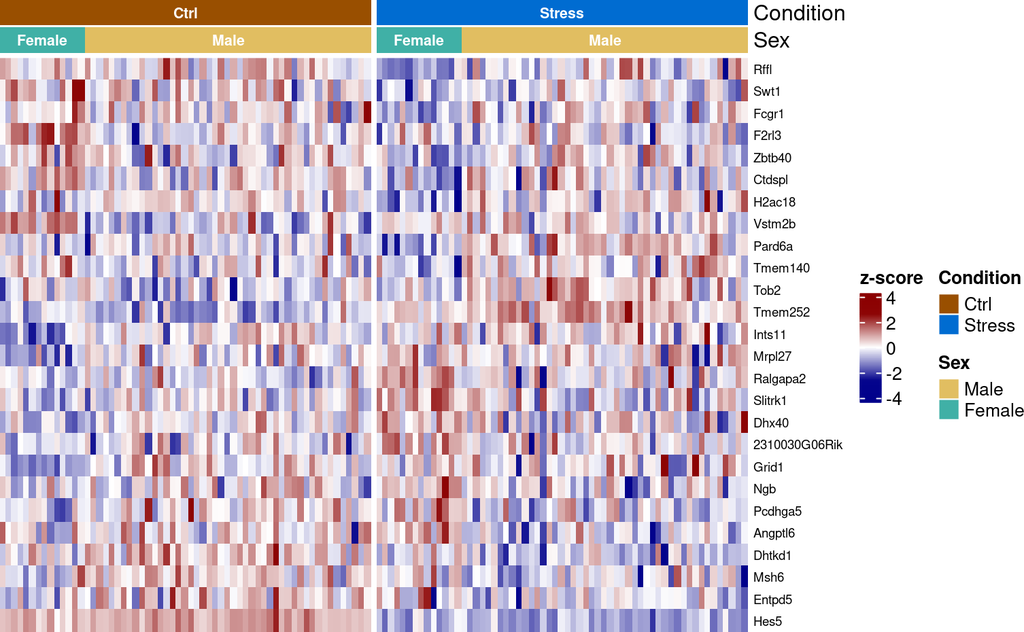

```r
cands2 <- intersect(intDEGs2, row.names(se)[which(rowData(se)$proteinCoding)])

sup_fig_coef_e <- sechm(
  se = se,
  feature = cands2,
  gaps_at = "Condition",
  assayName = "corrected",
  do.scale = TRUE,
  row_names_gp = gpar(fontsize=7),
  name = "z-score",
  top_annotation = c("Condition", "Sex"),
  anno_labels = TRUE,
  anno_label_gp = list(size = 8, col = "white"),  breaks = 0.99,
  row_labels = gsub(".+\\.","",cands2),
  use_raster = TRUE,
  column_title = NULL
)
sup_fig_coef_e
```

## 1.9 Top ten genes with a significant interaction and the largest interaction logFC

```r
intDF <- Results_interaction[order(abs(Results_interaction$logFC), decreasing = TRUE), ]
top10cand <- head(intDF[which(intDF$staged.FDR < 0.05 & abs(intDF$logFC) > 0.1 & rownames(intDF) %in% cands2),], 10)   # top10 candidates (protein-coding)
gsub(".+\\.","", rownames(top10cand))
```

```
##  [1] "H2ac18"        "F2rl3"         "Tmem252"       "Tmem140"
##  [5] "2310030G06Rik" "Ngb"           "Hes5"          "Fcgr1"
##  [9] "Pcdhga5"       "Angptl6"
```

They are the same genes from the top10 candidates from the reference analysis.

## 1.10 F. Compare with Brivio geneset

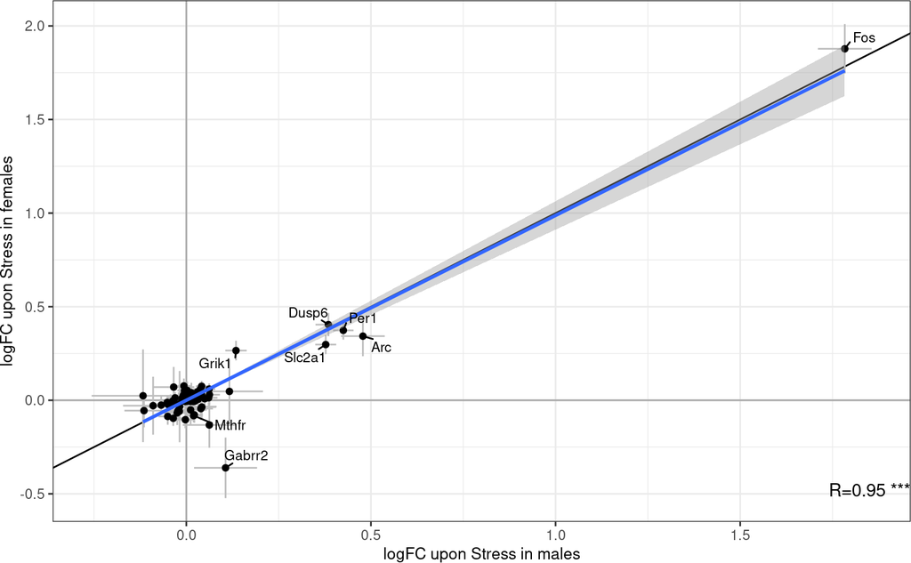

```r
brivioGenes <- tools::toTitleCase(tolower(readLines("./datasets/BrivioSexStressGenes2.txt")))
brivioGenes <- getrn(se, brivioGenes)
# check if they overlap with intDEGs:
overlap_gene <- intersect(brivioGenes, intDEGs)
# only Mthfr overlaps

merge_M_F <- merge(Results_M, Results_F, by="row.names", suffix=c(".males",".females"))
merge_M_F_brivio <- merge_M_F[which(merge_M_F$Row.names %in% brivioGenes),]
ct <- cor.test(merge_M_F_brivio$logFC.males, merge_M_F_brivio$logFC.females)
sup_fig_coef_f <- ggplot(merge_M_F_brivio, aes(logFC.males, logFC.females)) +
  geom_vline(xintercept = 0, colour = "darkgray") +
  geom_hline(yintercept = 0, colour = "darkgray") +
  geom_abline(slope = 1) +
  geom_segment(aes(y = low.females, yend = high.females), color = "grey") +
  geom_segment(aes(x = low.males, xend = high.males), color = "grey") +
  theme_bw() +
  theme(axis.title = element_text(size = 10)) +
  geom_point() +
  geom_smooth(formula = y ~ 0 + x, method = "lm") +
  ggrepel::geom_text_repel(data = merge_M_F_brivio[which(abs(merge_M_F_brivio$logFC.males) > 0.25 | abs(merge_M_F_brivio$logFC.females) > 0.25), ],
    aes(label = gsub(".+\\.","",Row.names)), max.overlaps = 30, min.segment.length = 0, size = 3) +
  ggrepel::geom_text_repel(data = merge_M_F_brivio[which(merge_M_F_brivio$Row.names %in% overlap_gene), ],
    aes(label = gsub(".+\\.","",Row.names)), nudge_x = 0.1, nudge_y = -0.05, max.overlaps = 30, min.segment.length = 0, size = 3) +
  labs(x = "logFC upon Stress in males", y = "logFC upon Stress in females") +
  annotate("text", x = Inf, y = -Inf, label = paste0(" R=", round(ct$estimate, 2), " ***\n"), hjust = 1, vjust = 0)
sup_fig_coef_f
```

## 1.11 G. Slope regression

In next chunk we ask: does female stress response differ systematically from male response? To answer this, we fit a regression of (female logFC - male logFC) ~ male logFC. We did this in three different gene sets: DEGs from full dataset; balanced DEGs; DEGs from balanced data.

```r
# Gene set 1. DEGs from differential analysis of the full dataset, both sexes pooled
merge_M_F <- merge(Results_M, Results_F, by = "row.names", suffix = c(".males",".females"))
m1 <- merge_M_F[which(merge_M_F$Row.names %in% row.names(Results_stress)[which(Results_stress$FDR < 0.05)]),]
# Here this gene set is selected form the analysis which is dominated by males (more samples in the data).
# So we might have detected more DEGs in males (since we have more power there), which could have led to a bias towards males
# # Thus we also use two other different gene sets.

# Gene set 2. balanced DEGs.
# Take the same number of top male DEGs as female DEGs, to avoid male-dominated gene selection
balanced_degs <- union(head(row.names(Results_M), sum(Results_F$FDR < 0.05)), row.names(Results_F)[which(Results_F$FDR < 0.05)])  # Since female has less significant genes than male, we extract the number of female DEGs
m2 <- merge_M_F[which(merge_M_F$Row.names %in% balanced_degs),]

# Gene set 3. DEGs from a sex-balanced dataset
# Here we select equal number of males and females, then re-run the differential analysis
# This also removes the power imbalance between sexes
# In this supplement, we only do subsampling once. (See reference analysis for the permutation)

set.seed(1234)
  # In our data, females only exist in two batches: Privitera.E2 and vonZiegler.E3
  # To balance also between different batches, we select 2 ctrl males and 3 stress males from Privitera.E1 batch (the reason to select from this batch is that in MDS plot, this batch is the closest one from batch vonZiegler.E3)
batch_with_both_sexes <- colnames(se)[se$Experiment %in% c("vonZiegler.E3", "Privitera.E2")]
male_ctrl_Privitera.E1 <- sample(colnames(se)[se$Experiment == "Privitera.E1" & se$group == "Male_Ctrl"], 2, replace = FALSE)
male_stress_Privitera.E1 <- sample(colnames(se)[se$Experiment == "Privitera.E1" & se$group == "Male_Stress"], 3, replace = FALSE)
se_sub <- se[,c(batch_with_both_sexes, male_ctrl_Privitera.E1, male_stress_Privitera.E1)]

# filter
dge <- DGEList(assay(se_sub, "counts"))
mm <- model.matrix(~ 0 + group, data=as.data.frame(colData(se_sub)))
dge <- calcNormFactors(dge)
# Filter lowly expressed genes
keep <- filterByExpr(dge, mm, min.count = 10)
se_sub <- se_sub[keep, ]

# SVA correction
suppressMessages(suppressWarnings(invisible(capture.output(
    se_sub <- SEtools::svacor(se_sub, ~ 0 + group, n.sv = 2, method = "vst")
  ))))

# DEA
formula <- paste(grep("^SV[0-9]", colnames(colData(se_sub)), value = TRUE), collapse = "+")
formula <- as.formula(paste0("~", formula, "+Sex*Condition"))
mm <- model.matrix(formula, data = as.data.frame(colData(se_sub)))
dge <- calcNormFactors(DGEList(assay(se_sub)))
dge <- estimateDisp(dge, mm)
fit <- glmQLFit(dge, mm, prior.count=0.5)

Results_stress_balanceddata <- as.data.frame(topTags(glmQLFTest(fit, grep("Condition", colnames(mm), value=TRUE)), Inf))

m3 <- merge_M_F[merge_M_F$Row.names %in% rownames(Results_stress_balanceddata)[Results_stress_balanceddata$FDR < 0.05], ]
nrow(m3)
```

```
## [1] 783
```

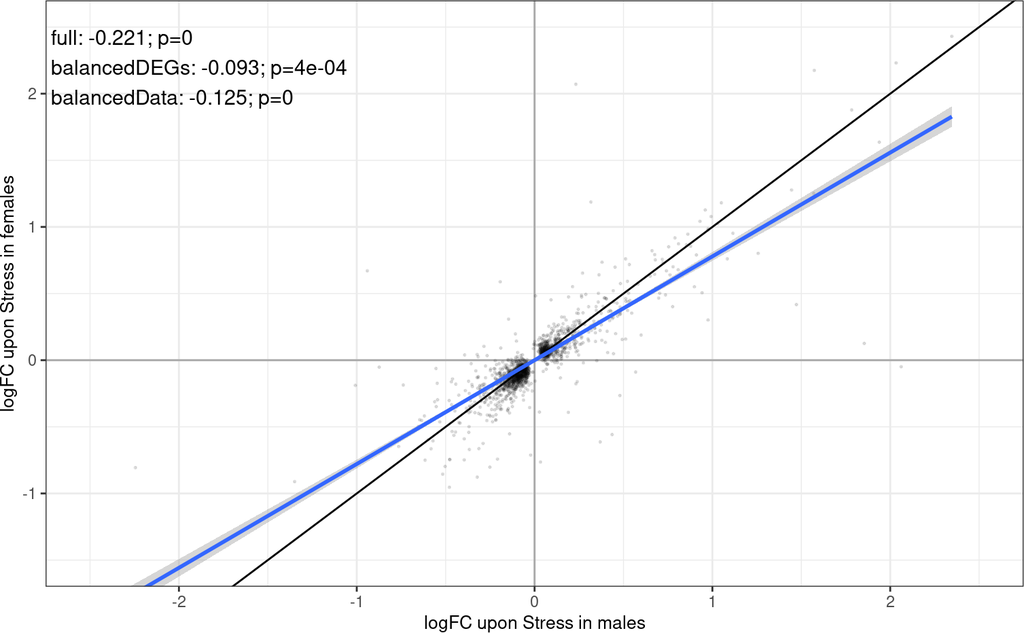

```r
# the number of DEGs are decent

# Linear regression on three gene sets: do females respond less than males?
# For each gene set: (femaleLogFC - maleLogFC) ~ maleLogFC
stats <- as.data.frame(t(sapply(list(full = m1, balancedDEGs = m2, balancedData = m3), \(x){
  coef(summary(lm(logFC.females - logFC.males ~ 0 + logFC.males, data = x)))[,-3]
  })))
stats$lab <- paste0(" ", row.names(stats), ": ", round(stats[,1], 3), "; p=", round(stats[,3], 4))

sup_fig_coef_g <- ggplot(m1, aes(logFC.males, logFC.females)) +
  geom_vline(xintercept = 0, colour = "darkgray") +
  geom_hline(yintercept = 0, colour = "darkgray") +
  theme_bw() +
  coord_cartesian(xlim = c(-2.5, 2.5), ylim = c(-1.5, 2.5)) +
  geom_abline(slope = 1) + geom_point(alpha = 0.1, size = 0.3) +
  geom_smooth(formula = y ~ 0 + x, method = "lm") +
  labs(x = "logFC upon Stress in males", y = "logFC upon Stress in females") +
  theme(axis.title = element_text(size = 10)) +
  annotate("text", label = paste0("\n",paste(stats$lab, collapse = "\n")), x = -Inf, y = Inf, hjust = 0, vjust = 1, size = 4)
sup_fig_coef_g
```

# 2 Save Objects for later use

```r
# save the result
stress_degs_MFunion <- union(M_signif, F_signif)
stressed_animals <- se[,se$Condition == "Stress"]$SampleName
mean_log2fc <- rowMeans(assay(se, "log2FC")[stress_degs_MFunion, stressed_animals])
filtered_stress_degs_MFunion <- mean_log2fc[abs(mean_log2fc) > 0.1]

DEGs <- list(
  MF_union_stress_degs = stress_degs_MFunion,
  MF_stress_degs_filtered = filtered_stress_degs_MFunion,
  Interaction_degs_stageR_by_allResults = intDEGs,
  Interaction_degs_stageR_by_subsetResults = intDEGs2)

coef_obj = list(se = se,
                   DEGs = DEGs,
                   edgeR = Results)
saveRDS(coef_obj, "./objects/coef_obj.rds")
```

# 3 Figure summary

```r
pdf("./supplements/supp_coefficient_analysis.pdf", width = 10, height = 10)
supp_coef <- plot_grid(
              plot_grid(sup_fig_coef_a + theme(legend.position = "none"),
                        as.ggplot(function() draw(sup_fig_coef_b, merge_legends = TRUE)) + theme(plot.margin = margin(0, 0, 22, 15)),
                        sup_fig_coef_c,
                        nrow = 1, labels = "AUTO", rel_widths = c(3,4,3)),
              plot_grid(sup_fig_coef_d,
                        as.ggplot(function() draw(sup_fig_coef_e, merge_legends = TRUE)) + theme(plot.margin = margin(0, 0, 22, 15)),
                        labels = LETTERS[4:5]),
              plot_grid(sup_fig_coef_f,
                        sup_fig_coef_g,
                        scale = 0.98, labels = LETTERS[6:7], nrow = 1, rel_widths = c(3,4)),
              nrow = 3)
supp_coef

pdf("./supplements/supp_coefficient_analysis.pdf", width = 10, height = 10)
supp_coef
dev.off()
```